# My Simple Logistic Regression

### Background

I will use logistic regression to try to predict mental illness based off of education level. Here is the logistic regression model:

$$P(Y_i = 1|\, x_i) = \frac{e^{\beta_0 + \beta_1 x_i}}{1+e^{\beta_0 + \beta_1 x_i}} = \pi_i$$

where for observation $i$:

- $Y_i = 1$ denotes that at least one education level predicts a mental illness,
- $Y_i=0$ denotes no education level predicts a metal illness, and
- $x_i$ denotes the specific education level being tested.

### Questions and Hypotheses

Question: Is education level a good predictor of mental illness?

Hypotheses: We will use the Deviance Goodness of Fit Test because there are replicated values of each $x_i$

$$H_0: \pi_i = \frac{e^{\beta_0 + \beta_1 x_i}}{1+e^{\beta_0 + \beta_1 x_i}}$$
$$H_a: \pi_i \neq \frac{e^{\beta_0 + \beta_1 x_i}}{1+e^{\beta_0 + \beta_1 x_i}}$$

### Analysis

Here is a logistic regression test:

```r
mental_glm <- glm(mental_illness ~ EducationLevel, data = employment, family = binomial)
summary(mental_glm) %>% pander()
```

|  | Estimate | Std. Error | z value | Pr(>\|z\|) |
| --- | --- | --- | --- | --- |
| **(Intercept)** | -0.9806 | 0.3829 | -2.561 | 0.01045 |
| **EducationLevel** | -0.05004 | 0.1025 | -0.4884 | 0.6253 |

(Dispersion parameter for binomial family taken to be 1 )

| Null deviance: | 354.2 on 321 degrees of freedom |
| --- | --- |
| Residual deviance: | 354.0 on 320 degrees of freedom |

##### I will use an alpha of 0.05:

Here we see that education level p-value is above 0.05 so it isn’t a good indication that it affects the probability of mental illness.

I will use the Deviance Goodness of Fit Test in order to determine if logistic regression is a good test to use because there are many repeated x-values.

Here is the value for the goodness of fit test:

```r
pander(pchisq(354.0, 320, lower.tail = FALSE))
```

*0.09254*

This value is above 0.05 remember that the null hypothesis was that logistic regression would be a good fit for the data so we can conclude the null.

### Graphical Summary

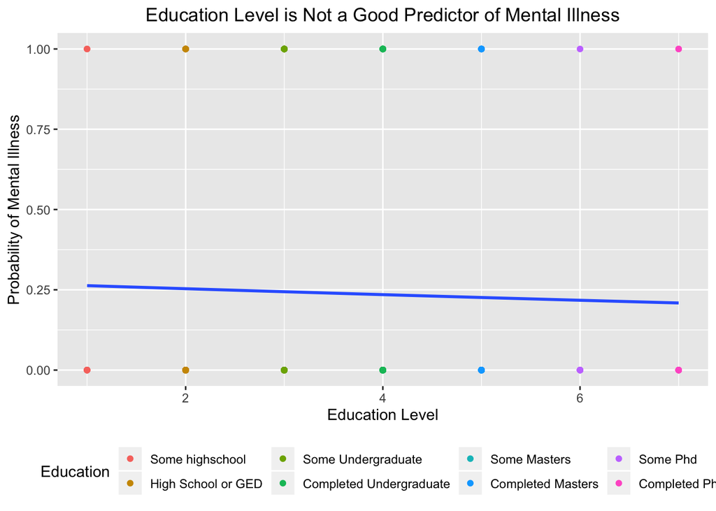

```r
ggplot(data = employment, mapping = aes(x = EducationLevel, y = mental_illness)) +
  geom_point(mapping = aes(color = Education)) +
  geom_smooth(method = "glm", method.args = list(family = "binomial"), se = FALSE) +
  labs(x = "Education Level", y = "Probability of Mental Illness", title = "Education Level is Not a Good Predictor of Mental Illness") +
  theme(legend.position = "bottom", plot.title = element_text(hjust = 0.5))
```

- Here we see the probabilities graphically. But we shouldn’t trust this beause our p-value for education level was too high. The logistic fit is good though.

### Interpretation

It seems like the education level of an individual is not a good indication of their mental health. There are probably some other variables that would be better to look at.